# Rstudio Tidyverse Certified Trainer Preparation Script

Shelmith

2/12/2020

Tidyverse is a collection of R packages designed for data science. The packages that are included in tidyverse include:

- readr: Used for reading in datasets into R.
- dplyr: Used for data manipulation.
- tidyr: Used for cleaning messy datasets.
- ggplot2: Used for generating graphs.
- forcats: Used for manipulating factor variables in R.
- lubridate: Used for working with dates
- tibble: Creates simple dataframes.
- stringr: Used for manipulating strings.
- purrr: USed for functional programming.

## Load the packages required

```r
#install.packages("tidyverse")
library(tidyverse)
library(rChambua)## Contains the dataset that we will use in this script (Wafanyikazi dataset)
```

```r
### 0.1 Install the libraries required
## Create a vector of packages to be installed
pkgs <- c("tidyverse","data.table","DT","lubridate","ggthemes","randomForest","readODS","ggcorrplot")

## Check if there are packages you want to load, that are not already installed.
miss_pkgs <- pkgs[!pkgs %in% installed.packages()[,1]]

## Installing the missing packages
if(length(miss_pkgs)>0){
  install.packages(miss_pkgs)
}
## Loading all the packages
invisible(lapply(pkgs,library,character.only=TRUE))

## Remove the objects that are no longer required
rm(miss_pkgs)
rm(pkgs)
```

## Read in the wafanyikazi dataset

```r
df <- wafanyikazi

#df <- read_csv("")
```

Used for picking and dropping variables.

```r
## Picking variables.

df1 <- df %>%
  select(Sid,Gender, Age)

## Dropping variables.
### When dopping variables, you insert a hyphen in front of the variable name.

df1 <- df %>%
  select(-Sid, -Promotion)

## Picking or dropping variables acording to a given pattern.

df1 <- df %>%
  select(contains("f")) ## Picking variables that contains letter e.

df1 <- df %>%
  select(-ends_with("t"))

## Picking a sequence of variables that appear together.

df1 <- df %>%
  select(Sid:Marital_Status)

rm(df1)
```

### 1.2 filter()

Used for picking values.

filter works with mathematical operators.

== equality != non-equality < less than > greater than & and | or

In english grammar, filter means removing unwanted material. But in R, we mostly use filter to keep observations, depending on the mathematical operators used.

```r
## Dropping obsevations based on the condition of a numeric variable.

### Let us drop all those who are aged 25 and above
df2 <- df %>%
  filter(Age < 25) ## notice the number is not enclosed in quotes


### Let us keep all those who are older than 25, but younger than 40
df2 <- df %>%
  filter(Age >= 25 & Age <40) ## notice the number is not enclosed in quotes

df2 <- df %>%
  filter(Age > 30 & Gender == "Female")

## Dropping obsevations based on the condition of a character/factor variable.
### Let us drop all males
df2 <- df %>%
  filter(Gender == "Female")

df2 <- df %>%
  filter(Gender != "Male")

rm(df2)
```

### 1.3 mutate()

Used for generating variables

```r
## Generating a basic variable.
df3 <- df %>%
  mutate(prop_leavedays = Leave_Days/365)

## Generating a variable, based on the conditions of another variable.
df3 <- df %>%
  mutate(Jinsia = if_else(Gender == "Female","Mke","Mme"))

rm(df3)
```

There are other variations of mutate(). mutate_all(): Used for implementing the same function on all of the variables.

mutate_at(): Used for implementing a function, for specific varibles. mutate_if(): Used for implementing a function, on specific variables, if they meet a certain condition.

#### 1.3.1: mutate_all()

The syntax is written as `mutate_all(~(function(.)))`. In the function, where a variable name should be inserted, replace that with a “period”, to signify all the variables.

```r
df4 <- df %>%
  mutate_all(~paste0(., "_x"))

df4 <- df %>%
  mutate_all(tolower)

rm(df4)
```

#### 1.3.2: mutate_at()

The syntax is written as `mutate_at(vars(), funs(.))`

```r
df4 <- df %>%
  mutate_at(vars(Gender, County), tolower)

df4 <- df %>%
  mutate_at(vars(Gender, County), funs(paste(.,"x")))

rm(df4)
```

#### 1.3.3: mutate_if()

The syntax is written as `mutate_if(condition, funs(.))`

```r
df4 <- df %>%
  mutate_if(is.numeric, funs(.*100))

df4 <- df %>%
  mutate_if(is.character, as.factor)

rm(df4)
```

### 1.4 group_by() and summarise()

Used for generating summary statistics.

```r
tab <- df %>%
  group_by(Gender) %>%
  count() %>%
  rename(Count = n)

tab <- df %>%
  group_by(Gender) %>%
  summarise(Count = n())

tab <- df %>%
  group_by(Department) %>%
  summarise(Avg_Income = mean(Income, na.rm = T))
```

#### 1.4.2 summarise_at

```r
tab <- df %>%
  group_by(County) %>%
  summarise_at(vars(Age, Leave_Days, Income), funs(mean(.,na.rm = TRUE)))
```

#### 1.4.2 summarise_if

```r
tab <- df %>%
  group_by(County,Gender) %>%
  summarise_if(is.numeric, funs(mean(.,na.rm = TRUE)))
```

### 1.5 arrange

Used for ordering the data based on certain variables

```r
df6 <- df %>%
  arrange(Gender, Age)

df6 <- df %>%
  arrange(Gender, desc(Age))
```

```r
## Generatin a dummy dataset
Year <- c(2010,2011,2012,2013,2014)
Q1 <-c(1003,1532,954,841,823)
Q2 <-c(1359,933,992,1434,1034)
Q3 <-c(1326,904,845,1480,1184)
Q4 <-c(1122,1479,889,1174,1317)

sales = data.frame(Year,Q1 ,Q2, Q3, Q4)
```

### 2.1 Wider to longer

```r
## Method 1: Using gather()

sales1 <- sales %>%
  gather("Quarters","Sales_Values", -Year, na.rm = TRUE)

## Method 2: Using pivot_longer()
sales2 <- sales %>%
  pivot_longer(-Year, names_to = "Quarters", values_to = "Sales_Values",values_drop_na = TRUE)
```

### 2.2 Longer to wider

```r
## Method 1: Using spread()
sales3 <- sales1 %>%
  spread(Quarters, Sales_Values)

## Method 2: Using pivot_wider()
sales4 <- sales2 %>%
  pivot_wider(names_from = "Quarters", values_from = "Sales_Values")
```

Used for creating beautiful graphs

```r
## Let us create a theme that we will use in this training

training_theme <- theme_hc()+
                  theme(legend.position = "right",
                  legend.direction = "vertical",
                  legend.title = element_blank(),
                  plot.title = element_text( size = rel(1.6), hjust = 0.5),
                  plot.subtitle = element_text(size = rel(1.5), hjust = 0.5),
                  axis.text.x = element_text(size =rel(1.5),angle = 0),
                  axis.text.y = element_text(size =rel(1.5),angle = 0),
                  axis.title = element_text( size = rel(1.55)),
                  axis.line.x = element_line(size = 1.5, colour = "black"),
                  panel.background = element_rect(fill = NA))

rstudio_blue <- "#4AA4DE"
```

### 3.1 geom_bar of one variable

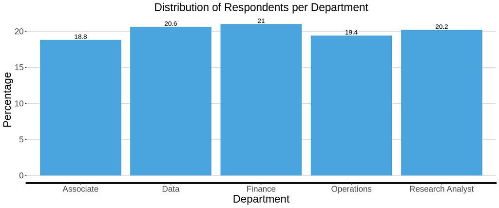

```r
## Let us generate a graph that sows us the number of individuals per department.

## First come up with the table showing frequencies and percentages.

tab <- df %>%
  group_by(Department) %>%
  count() %>%
  rename(Count = n) %>%
  ungroup() %>%
  mutate(Percentage = round(Count/ sum(Count) *100,1))

## Generate the graph
bargraph1 <- ggplot(data = tab, aes(x = Department, y = Percentage))+
             geom_bar(stat = "identity", fill = rstudio_blue)+
             geom_text(aes(label = Percentage), vjust = -0.25, hjust = 0.5, size=4)+
             training_theme+
             labs(title = "Distribution of Respondents per Department", x="Department",
                  y="Percentage")

bargraph1
```

### 3.2 geom_bar of more than one variable

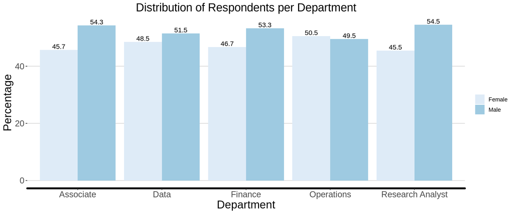

```r
## Let us generate a graph that sows us the number of individuals per department and gender category.

## First come up with the table showing frequencies and percentages.

tab <- df %>%
  group_by(Department, Gender) %>%
  count() %>%
  rename(Count = n) %>%
  ungroup() %>%
  group_by(Department) %>%
  mutate(Percentage = round(Count/ sum(Count) *100,1))

## Generate the graph
bargraph2 <- ggplot(data = tab, aes(x = Department, y = Percentage, fill=Gender))+
             geom_bar(stat = "identity", position = "dodge")+
             geom_text(aes(label = Percentage), vjust = -0.25, hjust = 0.5, size=4,position = position_dodge(width = 0.9))+
             training_theme+
             scale_fill_brewer(palette = "Blues")+
             labs(title = "Distribution of Respondents per Department", x="Department",
                  y="Percentage")
bargraph2
```

### 3.3 geom_line of one variable

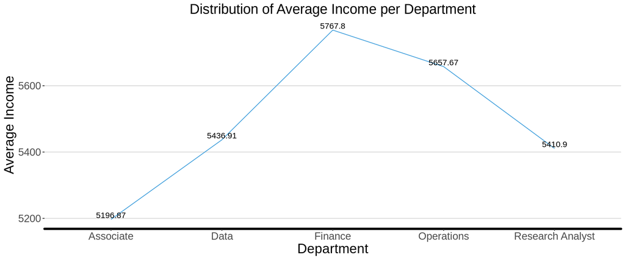

```r
## Let us generate a graph that sows us the average income per department.

## First come up with the table showing frequencies and percentages.

tab <- df %>%
  group_by(Department) %>%
  summarise(avg_income = round(mean(Income, na.rm = T), 2))

## Generate the graph
linegraph1 <- ggplot(data = tab, aes(x = Department, y = avg_income, group = 1))+
             geom_line(stat = "identity", color = rstudio_blue)+
             geom_text(aes(label = avg_income), vjust = -0.25, hjust = 0.5, size=4)+
             training_theme+
             labs(title = "Distribution of Average Income per Department", x="Department",
                  y="Average Income")
linegraph1
```

### 3.4 geom_line of 2 variables

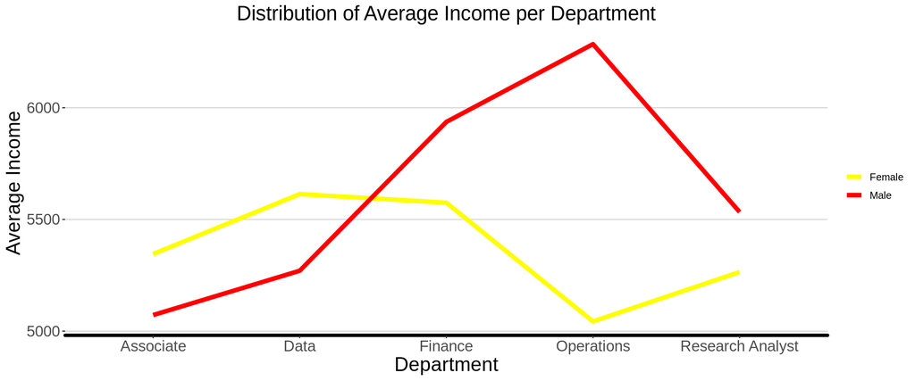

```r
## Let us generate a graph that sows us the average income per department and gender.

## First come up with the table showing frequencies and percentages.

tab <- df %>%
  group_by(Department, Gender) %>%
  summarise(avg_income = round(mean(Income, na.rm = T), 2))

## Generate the graph
linegraph2 <- ggplot(data = tab, aes(x = Department, y = avg_income, group = Gender, color = Gender))+
             geom_line(stat = "identity", size = 2)+
             training_theme+
             scale_color_manual(values = c("Yellow", "Red"))+
             labs(title = "Distribution of Average Income per Department", x="Department",
                  y="Average Income")
linegraph2
```

### 3.5 geom_boxplot of one variable

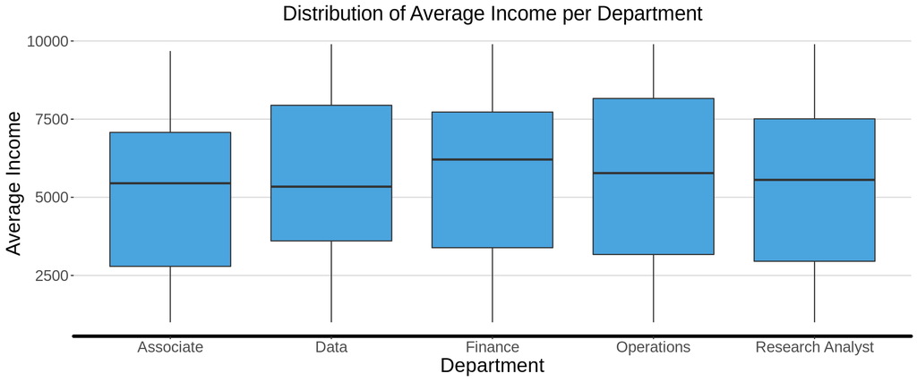

```r
## Let us generate a graph that sows us the average income per department.

## Generate the graph
boxplot1 <- ggplot(data = df, aes(x = Department, y = Income))+
             geom_boxplot( fill = rstudio_blue)+
             training_theme+
             labs(title = "Distribution of Average Income per Department", x="Department",
                  y="Average Income")
boxplot1
```

### 3.6 geom_boxplot of two variables

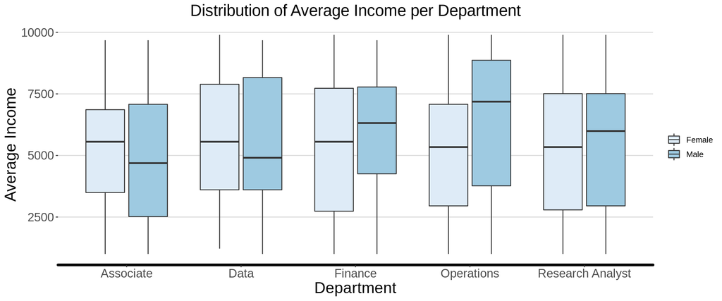

```r
## Let us generate a graph that sows us the average income per department and gender.

## Generate the graph
boxplot2 <- ggplot(data = df, aes(x = Department, y = Income, fill = Gender))+
             geom_boxplot()+
             training_theme+
             scale_fill_brewer(palette = "Blues")+
             labs(title = "Distribution of Average Income per Department", x="Department",
                  y="Average Income")
boxplot2
```

### 3.7 geom_area of one variable

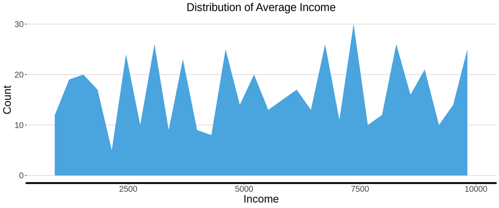

```r
## Let us generate a graph that sows us the average income per department and gender.

## Generate the graph
area1 <- ggplot(data = df, aes(x = Income))+
             geom_area(stat = "bin", fill = rstudio_blue)+
             training_theme+
             labs(title = "Distribution of Average Income", x="Income",
                  y="Count")
area1
```

### 3.8 geom_area of two variables

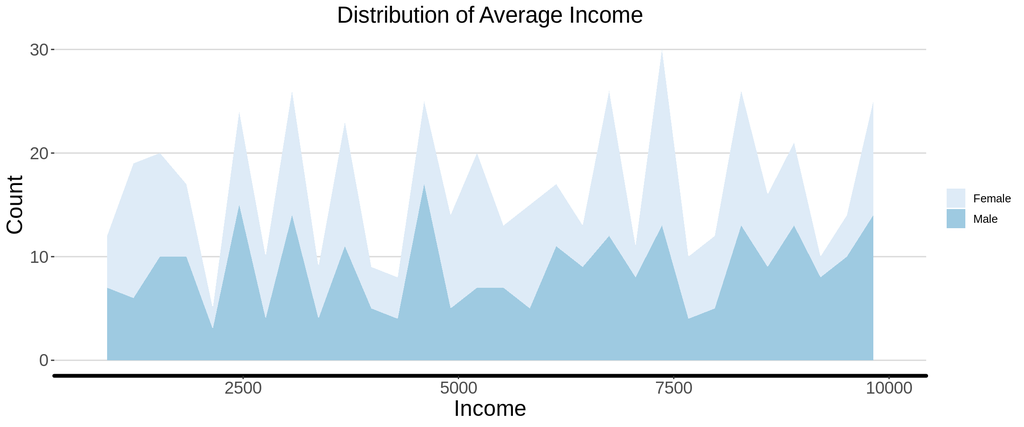

```r
## Let us generate a graph that sows us the average income per department and gender.

## Generate the graph
area2 <- ggplot(data = df, aes(x = Income, fill = Gender))+
             geom_area(stat = "bin")+
             training_theme+
             scale_fill_brewer(palette = "Blues")+
             labs(title = "Distribution of Average Income", x="Income",
                  y="Count")
area2
```

### 3.9 geom_histogram of one variable

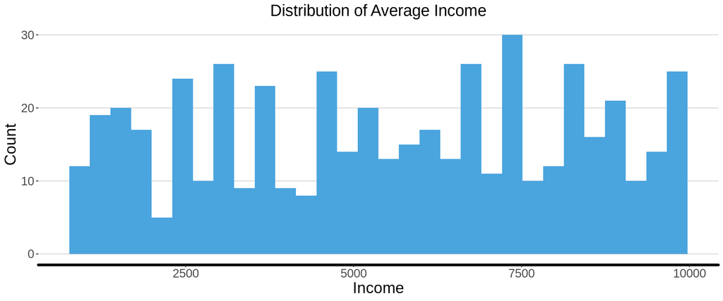

```r
## Let us generate a graph that sows us the average income per department and gender.

## Generate the graph
hist1 <- ggplot(data = df, aes(x = Income))+
             geom_histogram(stat = "bin", fill = rstudio_blue)+
             training_theme+
             labs(title = "Distribution of Average Income", x="Income",
                  y="Count")
hist1
```

### 3.10 geom_histogram of two variables

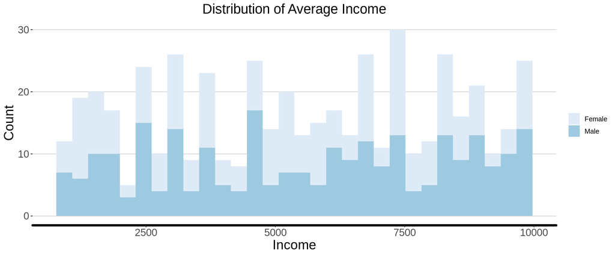

```r
## Let us generate a graph that sows us the average income per department and gender.

## Generate the graph
hist2 <- ggplot(data = df, aes(x = Income, fill = Gender))+
             geom_histogram(stat = "bin")+
             training_theme+
             scale_fill_brewer(palette = "Blues")+
             labs(title = "Distribution of Average Income", x="Income",
                  y="Count")
hist2
```